# BOO 2025 - Example Analysis

Script 4: PCA - Questions

Jurgen Zwerwer

2025-05-16

> In this script, you will perform principal component analysis (PCA) to further explore patterns in the project data.

# 1 Setup

## 1.1 Clean

As before, we perform several setup steps at the start of the script to ensure our work is reproducible and clear.

**Exercise 1: Download the R markdown template, clean your environment, and set the following variables:**

- `root_dir` - project folder
- `cpm_path` - location of the `cpmData` object
- `metadata_path` - location of the `metaData` object

```r
root_dir <- "~/Documents/BOO 2025 Code/Project/QC/Output/"
cpm_path <- "cpmData_QC.Rdata"
count_path <- "countData_QC.Rdata"
metadata_path <- "metaData_QC.Rdata"
```

## 1.2 Packages

Two new packages are introduced in this script:

- `ComplexHeatmap` allows the drawing and annotation of heatmaps in R
- `circlize` allows for the drawing of circular plots, but is also used by `ComplexHeatmap` for colour functions like `colorRamp2()`

**Exercise 2: Load these packages alongside `tidyverse` into your R environment:**

```r
library(ComplexHeatmap)
library(circlize)
library(tidyverse)
```

## 1.3 Load data

**Exercise 3: Load the CPM and metadata into your R environment:**

```r
load(paste0(root_dir, cpm_path))
load(paste0(root_dir, count_path))
load(paste0(root_dir, metadata_path))
```

# 2 PCA

## 2.1 Calculate

In high dimensional data (such as this data with around 10,000 genes), principal components (PCs) can be calculated and used to explore patterns. PCs can be thought of as a new axis in the data that captures the most variance possible in the fewest variables.

**Exercise 4: Use the `prcomp()` function to calculate PCs of the `cpmData`:**

```r
# The PCs that capture CPM data variance are calculated
pcs <- prcomp(t(cpmData))
```

Tolerance (or `tol`) can be adjusted to create more or fewer PCs, where a lower tolerance generates a higher number. If this argument is not set, the PCs calculated will capture the full variability of the CPM data.

## 2.2 Variance explained

**Exercise 5: Use the output of `prcomp()` to explore your PCs and calculate the variance in CPM values that they explain:**

**Hint**

Variance explained is the SD squared divided by the sum of the variance for all PCs.

```r
# First the PCs are summarized
summary(pcs)
```

```
## Importance of components:
##                              PC1       PC2       PC3       PC4       PC5
## Standard deviation     2095.8140 1293.4248 930.81808 713.22320 604.75130
## Proportion of Variance    0.4351    0.1657   0.08583   0.05039   0.03623
## Cumulative Proportion     0.4351    0.6009   0.68671   0.73711   0.77334
##                              PC6       PC7      PC8       PC9      PC10
## Standard deviation     584.15431 500.09434 453.7313 419.93296 329.59212
## Proportion of Variance   0.03381   0.02478   0.0204   0.01747   0.01076
## Cumulative Proportion    0.80714   0.83192   0.8523   0.86979   0.88055
##                             PC11     PC12      PC13      PC14      PC15
## Standard deviation     282.61456 271.5027 255.46912 237.40481 224.09744
## Proportion of Variance   0.00791   0.0073   0.00647   0.00558   0.00498
## Cumulative Proportion    0.88846   0.8958   0.90223   0.90781   0.91279
##                             PC16      PC17      PC18      PC19      PC20
## Standard deviation     213.32037 207.04674 201.26164 193.94657 178.93989
## Proportion of Variance   0.00451   0.00425   0.00401   0.00373   0.00317
## Cumulative Proportion    0.91729   0.92154   0.92555   0.92928   0.93245
##                             PC21      PC22      PC23      PC24      PC25
## Standard deviation     170.11657 169.03134 163.31849 155.91315 154.55151
## Proportion of Variance   0.00287   0.00283   0.00264   0.00241   0.00237
## Cumulative Proportion    0.93532   0.93815   0.94079   0.94320   0.94557
##                             PC26      PC27      PC28      PC29      PC30
## Standard deviation     150.46106 145.78726 144.76991 139.73977 139.27178
## Proportion of Variance   0.00224   0.00211   0.00208   0.00193   0.00192
## Cumulative Proportion    0.94781   0.94992   0.95199   0.95393   0.95585
##                             PC31      PC32      PC33      PC34      PC35
## Standard deviation     136.75149 132.18799 130.78547 128.39860 127.64521
## Proportion of Variance   0.00185   0.00173   0.00169   0.00163   0.00161
## Cumulative Proportion    0.95770   0.95943   0.96113   0.96276   0.96437
##                             PC36      PC37      PC38      PC39      PC40
## Standard deviation     126.12534 125.32686 124.43682 123.59162 121.94655
## Proportion of Variance   0.00158   0.00156   0.00153   0.00151   0.00147
## Cumulative Proportion    0.96595   0.96751   0.96904   0.97055   0.97203
##                             PC41      PC42      PC43      PC44      PC45
## Standard deviation     120.40960 118.12649 116.67782 115.44392 114.86221
## Proportion of Variance   0.00144   0.00138   0.00135   0.00132   0.00131
## Cumulative Proportion    0.97346   0.97484   0.97619   0.97751   0.97882
##                            PC46      PC47      PC48     PC49      PC50
## Standard deviation     114.3660 112.79086 111.12061 110.2610 109.59673
## Proportion of Variance   0.0013   0.00126   0.00122   0.0012   0.00119
## Cumulative Proportion    0.9801   0.98138   0.98260   0.9838   0.98499
##                             PC51      PC52      PC53      PC54     PC55
## Standard deviation     108.58226 108.08173 107.48904 106.71739 105.3514
## Proportion of Variance   0.00117   0.00116   0.00114   0.00113   0.0011
## Cumulative Proportion    0.98616   0.98732   0.98846   0.98959   0.9907
##                             PC56      PC57      PC58     PC59     PC60     PC61
## Standard deviation     103.63229 102.85195 102.30122 99.86246 99.14808 96.12309
## Proportion of Variance   0.00106   0.00105   0.00104  0.00099  0.00097  0.00092
## Cumulative Proportion    0.99176   0.99280   0.99384  0.99483  0.99580  0.99672
##                            PC62     PC63    PC64     PC65      PC66
## Standard deviation     94.85897 91.95014 89.9861 87.05453 5.471e-12
## Proportion of Variance  0.00089  0.00084  0.0008  0.00075 0.000e+00
## Cumulative Proportion   0.99761  0.99845  0.9992  1.00000 1.000e+00
```

```r
# Then the explained variance is calculated
var_explained =
  data.frame(PC = 1:nrow(Gene_meta),
             var_explained = round(pcs$sdev^2 / sum(pcs$sdev^2), 3))

var_explained
```

| PC | var_explained |
| --- | --- |
| 1 | 0.435 |
| 2 | 0.166 |
| 3 | 0.086 |
| 4 | 0.050 |
| 5 | 0.036 |
| 6 | 0.034 |
| 7 | 0.025 |
| 8 | 0.020 |
| 9 | 0.017 |
| 10 | 0.011 |

[output cut: 56 more lines]

## 2.3 Screeplot

A screeplot can be used to visualize how each subsequent PC captures less and less of the total variance in the data.

**Exercise 6: Plot the top 20 calculated PCs against the variance they explain to generate a screeplot:**

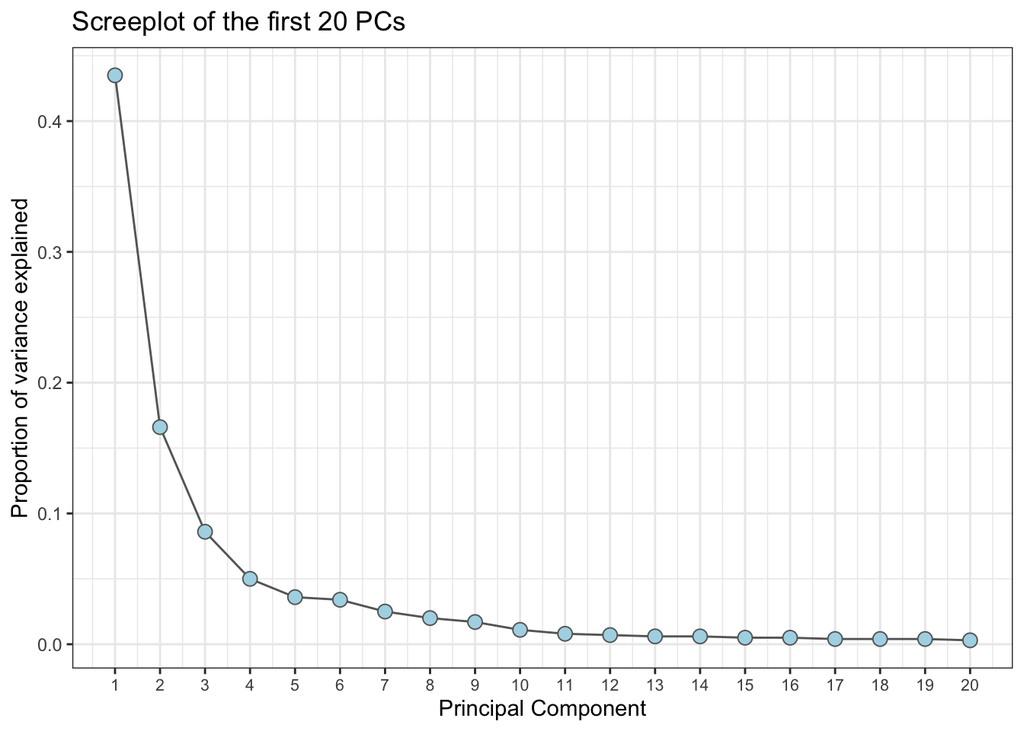

```r
var_explained %>% filter(PC <= 20) %>%

ggplot(aes(x=PC, y = var_explained)) +
  geom_line(color = "grey40") +
  geom_point(color = "grey40", fill = 'lightblue', shape = 21, size = 3) +
  scale_x_continuous(breaks = c(seq(1,20))) +
  xlab("Principal Component") +
  ylab("Proportion of variance explained") +
ggtitle("Screeplot of the first 20 PCs") +  theme_bw() +
  theme(axis.text.x = element_text(size = 8))
```

## 2.4 Relation to known variables

By investigating how PCs correlate with known variables, we can assess how much each factor impacts expression.

**Exercise 7: Add the PCs that explain more than 1% variance in CPM values to the metaData for further investigation:**

```r
# The first 10 PCs are added to the metadata
Gene_meta <- cbind(Gene_meta, pcs$x[,1:10])
```

Correlations between known factors and PCs can be calculated using the `cor()` function, which was used for the replicate correlation in the sample QC.

**Exercise 8: Generate a matrix of correlations between PCs explaining over 1% of CPM variance and known factors**

**Hint**

```r
# The SD of each column was calculated in Gene_meta
plot_vars <- apply(Gene_meta, 2, function(x) sd(as.numeric(factor(x)), na.rm=T))
# Column names that vary are saved (SD is not NA or 0)
plot_vars <- names(plot_vars[!plot_vars %in% c(NA, 0)])
# PC column names are then removed
plot_vars <- plot_vars[!grepl("PC", plot_vars)]

plot_vars
```

```
##  [1] "sample_ID"       "sample_type"     "compound_ID"     "compound_CAS"
##  [5] "compound_name"   "compound_abbr"   "mean_ID"         "mean_ID_control"
##  [9] "control_type"    "conc_ID"         "conc_amt"        "rep"
## [13] "lib_size"        "read_depth"      "plate_ID"        "plate_well"
## [17] "plate_row"       "plate_col"       "batch"           "compound_class"
## [21] "LOAEL_amt"       "PBPK_equivalent" "max_r2"
```

```r
# We subset Gene_meta to include only these columns
heatmap_df <- Gene_meta %>% select(any_of(plot_vars))

# All variables are converted to numeric values
heatmap_df <- apply(heatmap_df, 2, function(x) as.numeric(factor(x)))

# Then we calculate correlations between the first 10 PCs and these numeric variables scaled
cxy <- round(cor(pcs$x[,1:10], scale(heatmap_df),
                 use = "pairwise.complete.obs"), 2)

as.data.frame(cxy)
```

|  | sample_ID | sample_type | compound_ID | compound_CAS | compound_name | compound_abbr | mean_ID | mean_ID_control | control_type | conc_ID | conc_amt | rep | lib_size | read_depth | plate_ID | plate_well | plate_row | plate_col | batch | compound_class | LOAEL_amt | PBPK_equivalent | max_r2 |
| --- | --- | --- | --- | --- | --- | --- | --- | --- | --- | --- | --- | --- | --- | --- | --- | --- | --- | --- | --- | --- | --- | --- | --- |
| PC1 | 0.31 | 0.02 | 0.20 | 0.78 | -0.59 | -0.59 | 0.37 | 0.24 | -0.26 | 0.13 | 0.23 | 0.12 | -0.11 | -0.11 | 0.83 | 0.13 | 0.10 | 0.11 | 0.78 | -0.78 | -0.78 | 0.78 | 0.06 |
| PC2 | 0.01 | 0.15 | -0.13 | 0.06 | -0.05 | -0.05 | 0.04 | -0.56 | -0.72 | 0.45 | 0.57 | -0.02 | -0.11 | -0.11 | -0.14 | 0.04 | 0.03 | 0.14 | 0.06 | -0.06 | -0.06 | 0.06 | -0.33 |
| PC3 | 0.26 | -0.21 | 0.28 | 0.45 | -0.32 | -0.32 | 0.30 | 0.21 | -0.06 | -0.21 | -0.11 | -0.26 | -0.26 | -0.26 | 0.25 | -0.22 | -0.19 | -0.25 | 0.45 | -0.45 | -0.45 | 0.45 | 0.25 |
| PC4 | 0.45 | -0.51 | 0.42 | 0.18 | -0.13 | -0.13 | 0.48 | -0.07 | -0.21 | -0.29 | 0.22 | -0.35 | 0.12 | 0.12 | 0.10 | 0.51 | 0.53 | -0.39 | 0.18 | -0.18 | -0.18 | 0.18 | 0.26 |
| PC5 | -0.44 | 0.48 | -0.47 | 0.12 | -0.08 | -0.08 | -0.39 | 0.10 | 0.04 | 0.30 | -0.15 | -0.45 | 0.37 | 0.37 | 0.14 | -0.11 | -0.16 | 0.52 | 0.12 | -0.12 | -0.12 | 0.12 | 0.10 |
| PC6 | -0.07 | 0.14 | -0.12 | 0.13 | -0.11 | -0.11 | -0.05 | 0.30 | 0.27 | 0.10 | -0.01 | 0.06 | -0.28 | -0.28 | 0.26 | -0.07 | -0.07 | 0.11 | 0.13 | -0.13 | -0.13 | 0.13 | -0.43 |
| PC7 | 0.00 | -0.04 | -0.05 | -0.31 | 0.27 | 0.27 | -0.01 | -0.27 | -0.12 | 0.14 | 0.31 | -0.03 | -0.13 | -0.13 | -0.04 | -0.07 | -0.04 | -0.12 | -0.31 | 0.31 | 0.31 | -0.31 | -0.21 |
| PC8 | -0.12 | 0.31 | -0.10 | 0.27 | -0.19 | -0.19 | -0.12 | 0.46 | 0.37 | 0.21 | -0.06 | -0.05 | 0.01 | 0.01 | 0.12 | -0.28 | -0.26 | 0.16 | 0.27 | -0.27 | -0.27 | 0.27 | -0.14 |
| PC9 | -0.07 | 0.02 | -0.09 | -0.11 | 0.07 | 0.07 | -0.05 | -0.30 | -0.29 | 0.05 | 0.09 | -0.07 | -0.27 | -0.27 | -0.03 | 0.21 | 0.18 | 0.10 | -0.11 | 0.11 | 0.11 | -0.11 | -0.18 |
| PC10 | -0.05 | 0.03 | -0.06 | -0.14 | 0.11 | 0.11 | -0.03 | -0.02 | 0.08 | 0.14 | 0.23 | -0.29 | -0.03 | -0.03 | -0.16 | 0.15 | 0.15 | -0.01 | -0.14 | 0.14 | 0.14 | -0.14 | 0.00 |

Such a correlation matrix can be visualized using a heatmap.

**Exercise 9: Create a heatmap of correlations between known factors and the selected PCs:**

**Hint**

`colorRamp2` can be used to generate a custom colour palette.

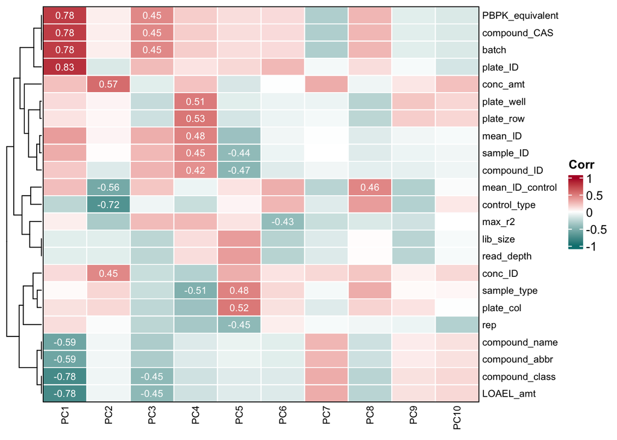

```r
# To visulize how correlated the variables are, a color scale from -1 to 1 for the heatmap is created.
col_fun <- colorRamp2(c(-1, 0, 1), c("#008080", "white", "#b3002d"))

# Then a heatmap is created
Heatmap(
  t(cxy),
  # A color palette is added
  col = col_fun,
  border = 'grey5',
  # Then the variables are clustered but not the PCs
  cluster_columns = FALSE,
  show_row_dend = TRUE,
  show_column_dend = FALSE,
  # The name of legend is set
  name = "Corr",
  # Then the text is formatted
  row_names_gp = gpar(fontsize = 8),
  column_names_gp = gpar(fontsize = 8),
  cell_fun = function(j, i, x, y, width, height, fill) {
    grid.rect(x, y, width, height,
              gp = gpar(col = "white", lwd = 1, fill = NA))
    # The correlation is printed if it is above 0.4
    grid.text(ifelse(abs(t(cxy)[i,j]) > 0.4,
                     sprintf("%.2f", round(t(cxy)[i, j], 2)),
                     ""),
              x, y, gp = gpar(fontsize = 8, col = "white"))
  }
)
```

PC1 and PC3 show high correlations. PC1 with plate_ID and PC3 with batch. PC4 also has high correlations but in other variables. PC1 was compared to both PC3 and PC4 below.